# R Notebook

## Load libraries

ggplot2 as our plotting library, dplyr to do a bit of data manipulation, ggrapel for fancy gene labels, IlluminaHumanv4.db as our reference database, and DBI as a utility package.

```r
library(ggplot2)
library(dplyr)
library(ggrepel)
library(illuminaHumanv4.db)
library(DBI)
```

## Prepping the Data

The `df` variable is a little more complex, but in order; convert the DE list to a dataframe, add the rownames as a variable (and call it `IlluminaID`), transform the adjusted P values to `-log10`, select only the Illumina ID, logFC and -log10 transformed p values. Now we have a simplified set of information for the volcano plot, we need some annotation, which is made easy until the `left_join` function. Finally, we set up two variables (`sig`/`SymbolPlot`), to show significant observations, and genes to label on the plot.

```r
load("~/Downloads/ForAndrew.RData")
lfc   <- log2(1.5)
pval  <- -log10(0.05)
anno  <- illuminaHumanv4fullReannotation() %>%
         as.data.frame %>%
         dplyr::slice(match(rownames(gene_list) %>% as.vector,IlluminaID)) %>%
         dplyr::select(IlluminaID,Symbol=SymbolReannotated)
# inter <- c("GSTP1", "KAT2B")
# ifelse(Symbol %in% inter, Symbol, "")
df    <- gene_list %>%
         as.data.frame %>%
         add_rownames("IlluminaID") %>%
         mutate(`-log10PVal` = -log10(`adj.P.Val`)) %>%
         dplyr::select(IlluminaID,logFC,`-log10PVal`) %>%
         left_join(anno) %>%
         mutate(Sig = ifelse((abs(logFC) > lfc & `-log10PVal` > pval), "Sig", ""),
                SymbolPlot = ifelse(`-log10PVal` > pval, Symbol, ""))
```

```
Deprecated, use tibble::rownames_to_column() instead.Joining, by = "IlluminaID"
```

```r
df
```

| IlluminaID | logFC | -log10PVal | Symbol | Sig | SymbolPlot |
| --- | --- | --- | --- | --- | --- |
| ILMN_2058782 | -1.3865161 | 0.15294058 | IFI27 |  |  |
| ILMN_1652431 | 1.0469313 | 0.28887925 | CA1 |  |  |
| ILMN_3274904 | 1.0454964 | 0.33499604 | RPL36A |  |  |
| ILMN_3279306 | 1.0387345 | 0.34586116 | RPL17 |  |  |
| ILMN_1656625 | 1.0233746 | 0.38520594 | RPS24 |  |  |
| ILMN_2383097 | 0.9957490 | 0.33870057 | RPL17 |  |  |
| ILMN_3290199 | 0.9740455 | 0.29537946 | RPL26 |  |  |
| ILMN_1731546 | 0.9734432 | 0.30654468 | RPL26 |  |  |
| ILMN_2139943 | 0.9584202 | 0.27326130 | RPS3A |  |  |
| ILMN_1695404 | -0.9152675 | 0.20673489 | LY6E |  |  |

[output cut: 990 more lines]

## Making a Volcano

Starting off simply, the x axis is the logFC, and the y axis is the -log10 transformed p value, additionally we colour by the `Sig` variable. Next we want to make points on our plot, and set the theme, followed by lines to illustrate cutoffs. The rest should be fairly straightforward.

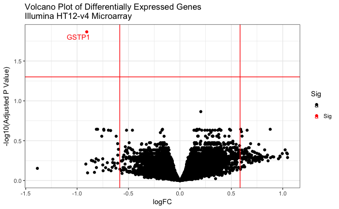

```r
gg    <- ggplot(df, aes(x = logFC, y = `-log10PVal`, colour = Sig)) +
         geom_point() + theme_bw() +
         geom_hline(yintercept = pval, colour = "red") +
         geom_vline(xintercept = c(lfc,-lfc), colour = "red") +
         scale_colour_manual(values = c("black", "red")) +
         ylab("-log10(Adjusted P Value)") +
         geom_text_repel(aes(label = df$SymbolPlot)) +
         ggtitle("Volcano Plot of Differentially Expressed Genes\nIllumina HT12-v4 Microarray")

print(gg)
```

[figure not shown]